# BISR: dynamic summary

Date: 2017-07-18

## Legend

The column `covariance` contains four ways in which the association between processes can be reported:  
- `Correlation` = correlation , estimated in Mplus  
- `Correlation CI` = Confidence intervals estimated in Mplus  
- `Covariance` = raw covariance  
- `Fisher's R` = correlation, computed outside of Mplus using Fisher’s transform from raw variances and covariances

Note: cases in which restricted (co)variances or insufficient decimals prevent the computation of correlations are marked by `---`

**Raw covariance** and **estimated correlations** are reported in the form : **`est(se) pval star`**,where  
- `est` is the covariance estimate on the original metric  
- `se` is the standard error on the original metric  
- `pval` is the p-value associated with the raw covariance  
- `star` is significance indicator associated with corresponding covariance estimate, with `.`, `*`, `**`, and `***` indicating significance at `.10`, `.05`, `.01`, and `.001` alpha levels, respectively

**Confidence intervals** for estimated correlations are reported in the form: **`(low,high)`**,where  
- `low` - bottom boundry of the 95% confidence interval - `high` - top boundry of the 95% confidence interval

**Computed correlations** are reported in the form: **`est(low, high)`**, where  
- `est` is the correlation coefficient computed from raw (co)variances using Fisher transfrom  
- `low` and `high` are the 95% confidence intervals associated with the computed correlations

# Dynamic Summary

|  | domain | study | subgroup | model_type | process_a | process_b | N | covariance | Levels | Slopes | Residuals |
| --- | --- | --- | --- | --- | --- | --- | --- | --- | --- | --- | --- |
| 1 | gait-grip | EAS | female | aehplus | grip | gait | 147 | Correlation | .17( .17), p=.31 | .38( .50), p=.44 | .03( .10), p=.78 |
| 2 | gait-grip | EAS | female | aehplus | grip | gait | 147 | Correlation CI | (-.17, .52) | (-.59,1.36) | (-.17, .22) |
| 3 | gait-grip | EAS | female | aehplus | grip | gait | 147 | Covariance | 16.31(16.92), p=.34 | .46( .74), p=.53 | .51(1.84), p=.78 |
| 4 | gait-grip | EAS | female | aehplus | grip | gait | 147 | Fisher's R | .18( .01, .33) | .38( .23, .51) | .03(-.14, .19) |
| 5 | gait-grip | EAS | male | aehplus | grip | gait | 72 | Correlation | .32( .45), p=.48 | .24(2.86), p=.93 | .21( .25), p=.39 |
| 6 | gait-grip | EAS | male | aehplus | grip | gait | 72 | Correlation CI | (-.57,1.20) | (-5.36,5.85) | (-.28, .71) |
| 7 | gait-grip | EAS | male | aehplus | grip | gait | 72 | Covariance | 23.89(37.41), p=.52 | .18(2.28), p=.94 | 7.76(10.60), p=.46 |
| 8 | gait-grip | EAS | male | aehplus | grip | gait | 72 | Fisher's R | .32( .09, .51) | .24( .01, .45) | .21(-.02, .43) |
| 9 | gait-grip | HRS | female | aehplus | grip | gait | 4208 | Correlation | .26( .04), p&lt;.01 *** | -.05( .21), p=.82 | .10( .02), p&lt;.01 *** |
| 10 | gait-grip | HRS | female | aehplus | grip | gait | 4208 | Correlation CI | ( .18, .34) | (-.46, .36) | ( .05, .15) |

[output cut: 190 more lines]

# Forest: slope

## gait-grip

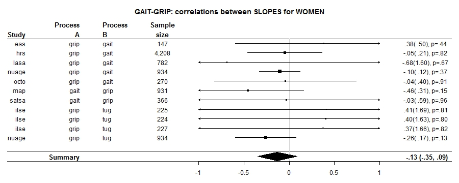

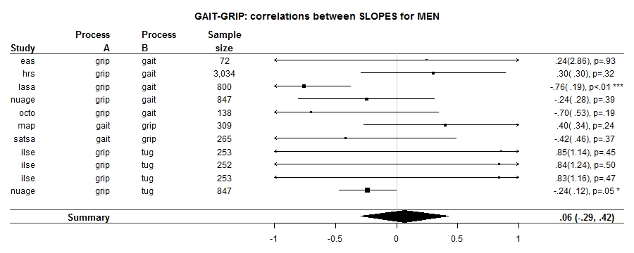

## pulmonary-gait

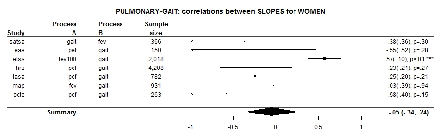

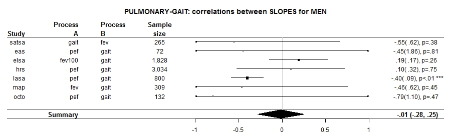

## pulmonary-grip

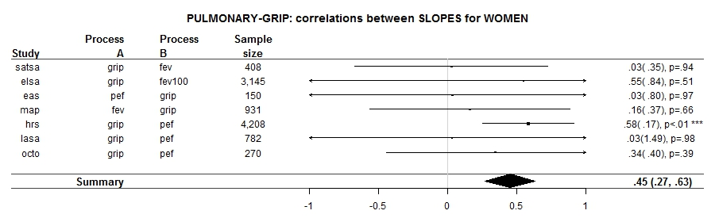

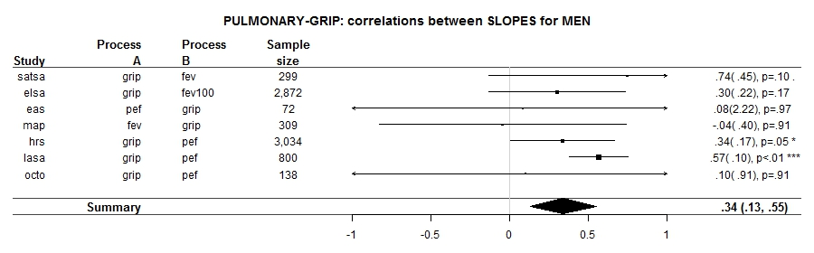

# Forest: residual

## gait-grip

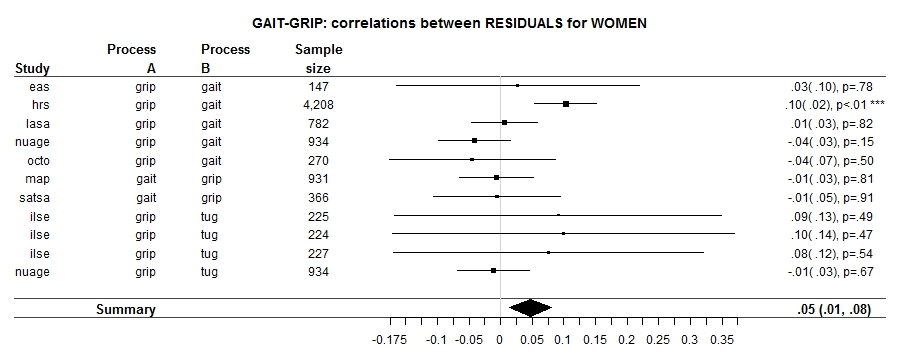

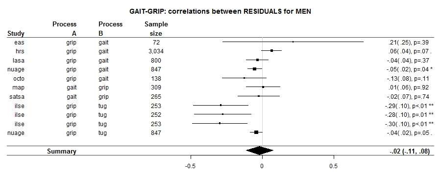

## pulmonary-gait

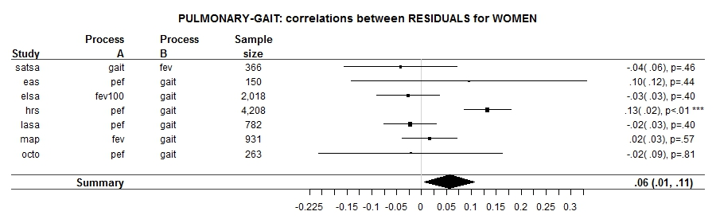

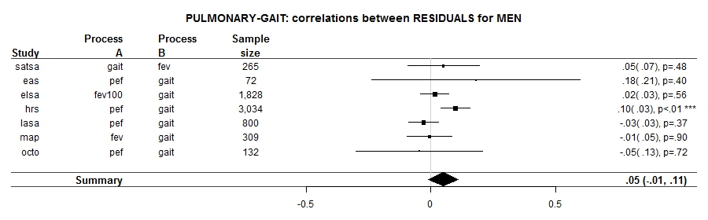

## pulmonary-grip

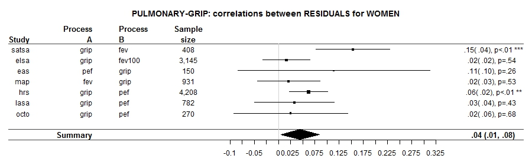

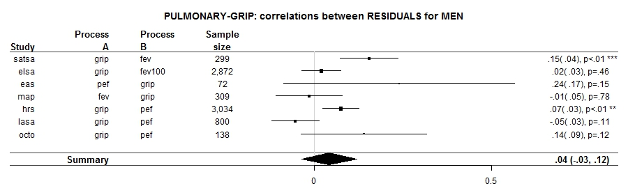

# Forest: intercept

## gait-grip

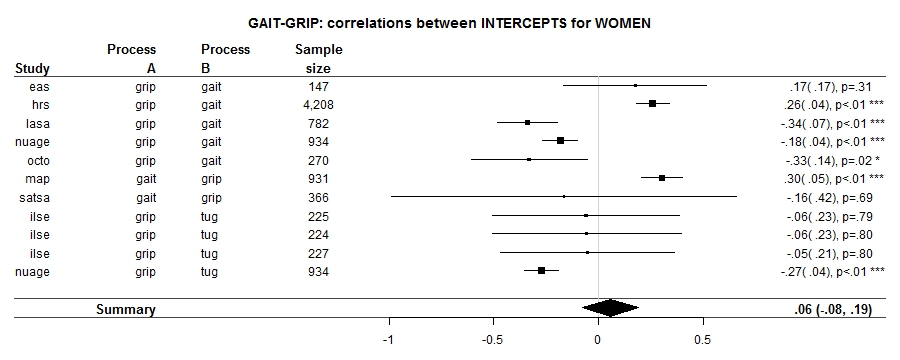

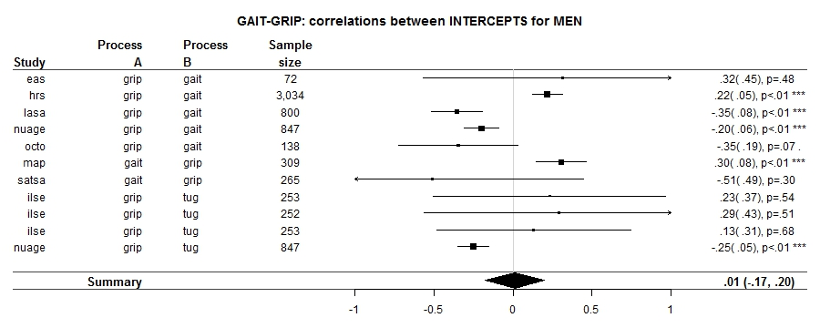

## pulmonary-gait

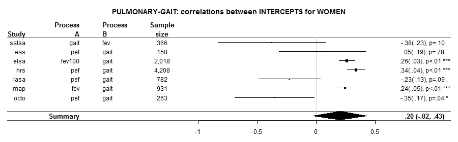

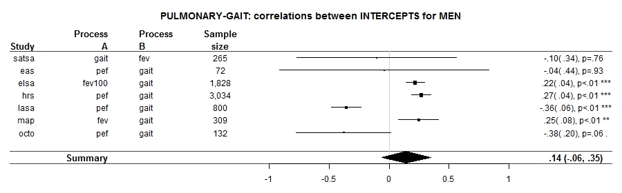

## pulmonary-grip

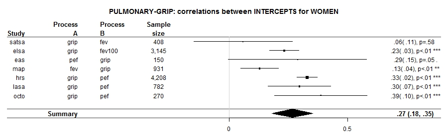

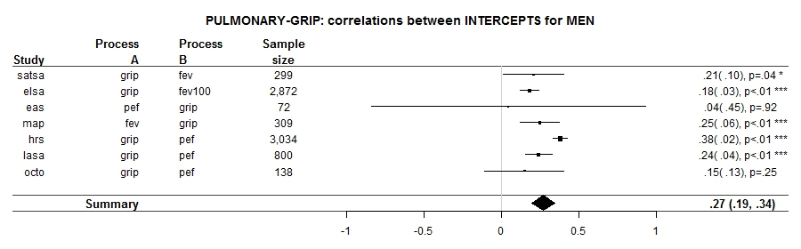

# Session Information

For the sake of documentation and reproducibility, the current report was rendered on a system using the following software.

```
Report rendered by koval_000 at 2017-07-18, 15:29 -0400
```